# Facharztmangel im Öffentlichen Gesundheitsdienst

Peter Tinnemann, Jakob Schumacher, Elke Bruns-Philipps, Ute Teichert

28 Februar, 2020

# Datenquelle

Die Daten stammen von den Ärztekammern. Sie werden bereitgestellt auf http://www.gbe-bund.de unter dem Tabellennamen: [“Ärztinnen und Ärzte mit Gebiets- und Facharztbezeichnung, BÄK”](http://www.gbe-bund.de/gbe10/express.prc_expr?p_aid=30416728&p_uid=gast&p_sprachkz=D&p_var=0&nummer=656&p_indsp=&p_ityp=H&p_hlpnr=3&p_lfd_nr=1&p_sprache=D&p_news=&p_janein=J)

Beschreibung der Methodik der Statistik der Mitglieder der (Landes-) Ärztekammern (Ärztestatistik) von gbe-bund.de

- *In den Heilberufsgesetzen der Bundesländer ist festgelegt, dass alle Ärzte, die in einem bestimmten Bundesland tätig sind oder, falls sie ihren Beruf nicht ausüben, ihren gewöhnlichen Aufenthalt haben, Mitglied der jeweiligen (Landes-) Ärztekammer sein müssen. Die Kammern haben über ihre Mitglieder ein Verzeichnis zu führen, in das bestimmte Angaben einzutragen sind. Auf der Basis dieser Mitgliederverzeichnisse erstellen die (Landes-) Ärztekammern zum 31. Dezember jeden Jahres Auswertungen zu ausgewählten Aspekten der Berufspolitik, die sie an die Bundesärztekammer weiterleiten. Die Bundesärztekammer (BÄK), Arbeitsgemeinschaft der deutschen Ärztekammern, ist die Berufsvertretung aller deutschen Ärzte auf Bundesebene. Die Bundesärztekammer fasst diese Meldungen zum Bundesergebnis zusammen und erstellt somit die Ärztestatistik.*

Beschreibung der Auswahl

1. Auswahl der Tabelle “Ärztinnen und Ärzte mit Gebiets- und Facharztbezeichnung, BÄK” auf GBE-Bund.de
2. Einschränkung auf der Seite “Werteauswahl” auf die Jahre 1998 bis 2018
3. Einschränkung auf der Seite “Werteauswahl” unter “Tätigkeitsbereiche” auf “mit ärztlicher Tätigkeit”
4. Einschränkung der Facharztrichtungen
   1. Wenn “alle Facharztrichtungen” beschrieben sind wurde auf der Seite “Werteauswahl” die folgenden ausgewählt: Allgemeinmedizin, Anästhesiologie, Anatomie, Arbeitsmedizin, Augenheilkunde, Biochemie, Chirurgie, Frauenheilkunde und Geburtshilfe, Hals-Nasen-Ohrenheilkunde, Haut- und Geschlechtskrankheiten, Humangenetik, Hygiene und Umweltmedizin, Innere Medizin, Kinder- und Jugendmedizin, Kinder- und Jugendpsychiatrie und -psychotherapie, Laboratoriumsmedizin, Mikrobiologie Virologie Infektionsepidemiologie, Mund-Kiefer-Gesichtschirurgie, Neurochirurgie, Neurologie, Nuklearmedizin, Öffentliches Gesundheitswesen, Pathologie, Pharmakologie, Physikalische und Rehabilitative Medizin, Physiologie, Psychiatrie und Psychotherapie, Psychosomatische Medizin und Psychotherapie, Radiologie, Rechtsmedizin, Strahlentherapie, Transfusionsmedizin, Urologie
   2. Wenn “Fachärzte im öffentlichen Gesundheitswesen” beschrieben ist wurde nur auf der Seite “Werteauswahl” ausgewählt: Öffentliches Gesundheitswesen

# Änderung Gesamtanzahl

Kummulierte prozentuale Änderung der Anzahl an tätigen Fachärzt/innen von 1998 bis 2018 nach Ärztlicher Tätigkeit unterschieden zwischen Gesamtheit aller Facharztrichtungen, in Behöroden/Körperschaften o.ä. und Öffentliches Gesundheitswesen

## Abbildung

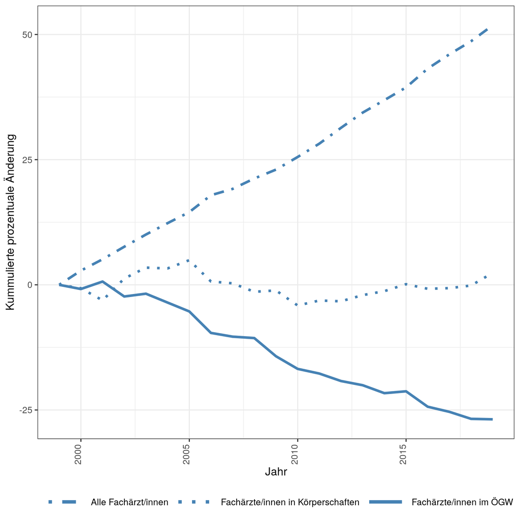

Kummulierte prozentuale Änderung der Anzahl der bei der Ärztekammer registrierten tätigen Fachärztinnen und Fachärzten in Deutschland von 1998 bis 2018

## Tabelle

| Ärztliche Tätigkeit | 2018 | 1998 | Prozentuale Veränderung |
| --- | --- | --- | --- |
| Gesamt | 274252 | 180624 | 52 |
| In Behörden/Körperschaften u. a. | 6470 | 6319 | 2 |
| Öffentliches Gesundheitswesen | 784 | 1072 | -27 |

## Anteil der Fachärzt/innen ÖGW

[output not shown]

# Nach Region

Bei den Ärztekammern registrierte tätigen Fachärt/innen für Öffentliches Gesundheitswesen nach Region von 1998 bis 2018 in Deutschland

## Abbildung

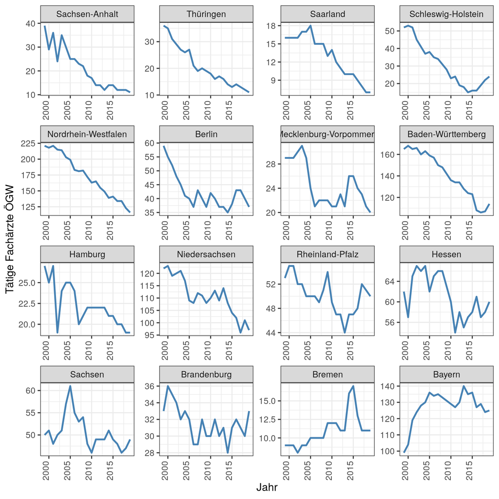

## Tabelle

| Region | 1998-12-31 | 2008-12-31 | 2018-12-31 | Verlust in Prozent |
| --- | --- | --- | --- | --- |
| Sachsen-Anhalt | 39 | 18 | 11 | -71.8 |
| Thüringen | 36 | 19 | 11 | -69.4 |
| Saarland | 16 | 13 | 7 | -56.2 |
| Schleswig-Holstein | 52 | 28 | 24 | -53.8 |
| Nordrhein-Westfalen | 221 | 172 | 116 | -47.5 |
| Berlin | 59 | 37 | 37 | -37.3 |
| Mecklenburg-Vorpommern | 29 | 22 | 20 | -31.0 |
| Baden-Württemberg | 165 | 142 | 114 | -30.9 |
| Hamburg | 27 | 22 | 19 | -29.6 |
| Deutschland | 1072 | 919 | 784 | -26.9 |
| Niedersachsen | 122 | 108 | 97 | -20.5 |
| Rheinland-Pfalz | 53 | 54 | 50 | -5.7 |
| Hessen | 62 | 63 | 60 | -3.2 |
| Sachsen | 50 | 48 | 49 | -2.0 |
| Brandenburg | 33 | 30 | 33 | 0.0 |
| Bremen | 9 | 12 | 11 | 22.2 |
| Bayern | 99 | 131 | 125 | 26.3 |

## Tabelle Anzahl pro 100.000

| Region | Anzahl pro 100.000 (2018) |
| --- | --- |
| Baden-Württemberg | 1.03 |
| Bayern | 0.96 |
| Berlin | 1.02 |
| Brandenburg | 1.31 |
| Bremen | 1.61 |
| Hamburg | 1.03 |
| Hessen | 0.96 |
| Mecklenburg-Vorpommern | 1.24 |
| Niedersachsen | 1.22 |
| Nordrhein-Westfalen | 0.65 |
| Rheinland-Pfalz | 1.22 |
| Saarland | 0.71 |
| Sachsen | 1.20 |
| Sachsen-Anhalt | 0.50 |
| Schleswig-Holstein | 0.83 |
| Thüringen | 0.51 |

# Nach Facharztrichtungen

## Abbildung

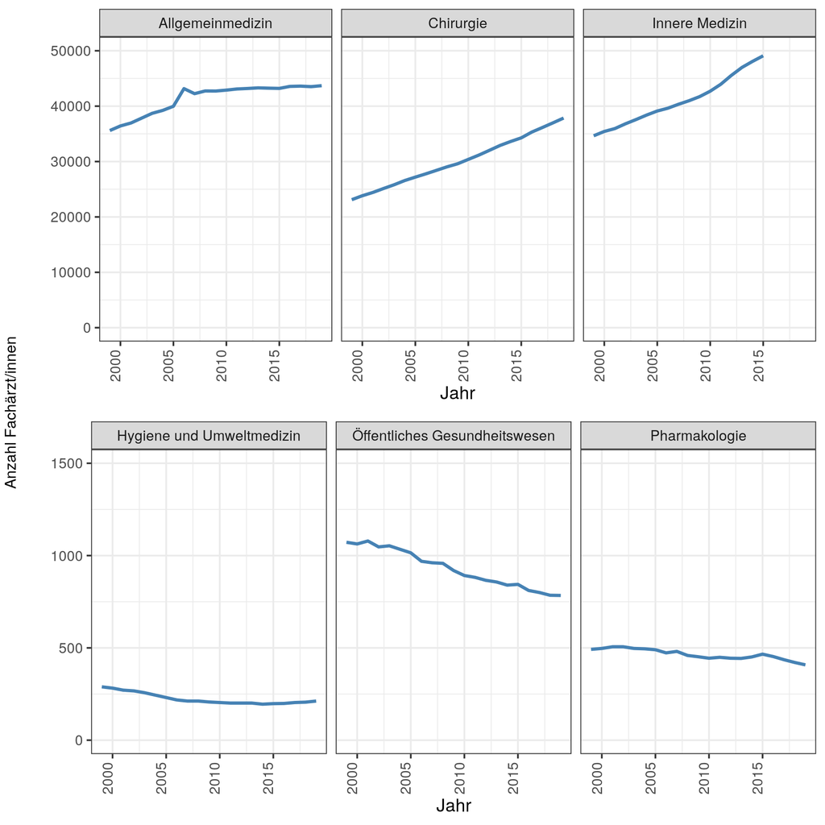

## Komprimierte Tabelle

| Facharzt | Anzahl im Jahr 1998 | Anzahl im Jahr 2018 | Kumulierte prozentuale Änderung |
| --- | --- | --- | --- |
| Biochemie | 93 | 37 | -60.2 |
| Öffentliches Gesundheitswesen | 1072 | 784 | -26.9 |
| Hygiene und Umweltmedizin | 289 | 212 | -26.6 |
| Anatomie | 134 | 110 | -17.9 |
| Pharmakologie | 492 | 408 | -17.1 |
| Physiologie | 119 | 101 | -15.1 |
| Rechtsmedizin | 220 | 263 | 19.5 |
| Augenheilkunde | 6305 | 7639 | 21.2 |
| Allgemeinmedizin | 35599 | 43697 | 22.7 |
| Hals-Nasen-Ohrenheilkunde | 5172 | 6383 | 23.4 |
| Laboratoriumsmedizin | 924 | 1146 | 24.0 |
| Frauenheilkunde und Geburtshilfe | 14327 | 18622 | 30.0 |
| Pathologie | 1314 | 1735 | 32.0 |
| Arbeitsmedizin | 2614 | 3519 | 34.6 |
| Kinder- und Jugendmedizin | 11044 | 14999 | 35.8 |
| Gesamt | 287032 | 392402 | 36.7 |
| Haut- und Geschlechtskrankheiten | 4429 | 6057 | 36.8 |
| Mikrobiologie, Virologie, Infektionsepidemiologie | 587 | 817 | 39.2 |
| Physikalische und Rehabilitative Medizin | 1303 | 1882 | 44.4 |
| Psychosomatische Medizin und Psychotherapie | 2872 | 4155 | 44.7 |
| Urologie | 4186 | 6075 | 45.1 |
| Transfusionsmedizin | 381 | 584 | 53.3 |
| Radiologie | 5725 | 8792 | 53.6 |
| Innere Medizin | 34653 | 54982 | 58.7 |
| Chirurgie | 23113 | 37853 | 63.8 |
| Nuklearmedizin | 724 | 1190 | 64.4 |
| Mund-Kiefer-Gesichtschirurgie | 1048 | 1766 | 68.5 |
| Anästhesiologie | 13779 | 24970 | 81.2 |
| Humangenetik | 151 | 359 | 137.7 |
| Kinder- und Jugendpsychiatrie und -psychotherapie | 910 | 2449 | 169.1 |
| Neurochirurgie | 867 | 2363 | 172.5 |
| Psychiatrie und Psychotherapie | 3760 | 11346 | 201.8 |
| Strahlentherapie | 457 | 1420 | 210.7 |
| Neurologie | 1961 | 7537 | 284.3 |

## Ausführliche Tabelle

| Facharzt | 1998-12-31 | 2008-12-31 | 2018-12-31 |
| --- | --- | --- | --- |
| Allgemeinmedizin | 35599 (0 %) | 42730 (20 %) | 43697 (22.7 %) |
| Anästhesiologie | 13779 (0 %) | 18327 (33 %) | 24970 (81.2 %) |
| Anatomie | 134 (0 %) | 104 (-22.4 %) | 110 (-17.9 %) |
| Arbeitsmedizin | 2614 (0 %) | 2728 (4.4 %) | 3519 (34.6 %) |
| Augenheilkunde | 6305 (0 %) | 6638 (5.3 %) | 7639 (21.2 %) |
| Biochemie | 93 (0 %) | 58 (-37.6 %) | 37 (-60.2 %) |
| Chirurgie | 23113 (0 %) | 29602 (28.1 %) | 37853 (63.8 %) |
| Frauenheilkunde und Geburtshilfe | 14327 (0 %) | 16134 (12.6 %) | 18622 (30 %) |
| Gesamt | 287032 (0 %) | 319697 (11.4 %) | 392402 (36.7 %) |
| Hals-Nasen-Ohrenheilkunde | 5172 (0 %) | 5566 (7.6 %) | 6383 (23.4 %) |
| Haut- und Geschlechtskrankheiten | 4429 (0 %) | 5180 (17 %) | 6057 (36.8 %) |
| Humangenetik | 151 (0 %) | 251 (66.2 %) | 359 (137.7 %) |
| Hygiene und Umweltmedizin | 289 (0 %) | 207 (-28.4 %) | 212 (-26.6 %) |
| Innere Medizin | 34653 (0 %) | 41722 (20.4 %) | 54982 (58.7 %) |
| Kinder- und Jugendmedizin | 11044 (0 %) | 11973 (8.4 %) | 14999 (35.8 %) |
| Kinder- und Jugendpsychiatrie und -psychotherapie | 910 (0 %) | 1503 (65.2 %) | 2449 (169.1 %) |
| Laboratoriumsmedizin | 924 (0 %) | 977 (5.7 %) | 1146 (24 %) |
| Mikrobiologie, Virologie, Infektionsepidemiologie | 587 (0 %) | 666 (13.5 %) | 817 (39.2 %) |
| Mund-Kiefer-Gesichtschirurgie | 1048 (0 %) | 1445 (37.9 %) | 1766 (68.5 %) |
| Neurochirurgie | 867 (0 %) | 1464 (68.9 %) | 2363 (172.5 %) |
| Neurologie | 1961 (0 %) | 4238 (116.1 %) | 7537 (284.3 %) |
| Nuklearmedizin | 724 (0 %) | 984 (35.9 %) | 1190 (64.4 %) |
| Öffentliches Gesundheitswesen | 1072 (0 %) | 919 (-14.3 %) | 784 (-26.9 %) |
| Pathologie | 1314 (0 %) | 1405 (6.9 %) | 1735 (32 %) |
| Pharmakologie | 492 (0 %) | 452 (-8.1 %) | 408 (-17.1 %) |
| Physikalische und Rehabilitative Medizin | 1303 (0 %) | 1684 (29.2 %) | 1882 (44.4 %) |
| Physiologie | 119 (0 %) | 95 (-20.2 %) | 101 (-15.1 %) |
| Psychiatrie und Psychotherapie | 3760 (0 %) | 7856 (108.9 %) | 11346 (201.8 %) |
| Psychosomatische Medizin und Psychotherapie | 2872 (0 %) | 3890 (35.4 %) | 4155 (44.7 %) |
| Radiologie | 5725 (0 %) | 6690 (16.9 %) | 8792 (53.6 %) |
| Rechtsmedizin | 220 (0 %) | 210 (-4.5 %) | 263 (19.5 %) |
| Strahlentherapie | 457 (0 %) | 933 (104.2 %) | 1420 (210.7 %) |
| Transfusionsmedizin | 381 (0 %) | 520 (36.5 %) | 584 (53.3 %) |
| Urologie | 4186 (0 %) | 5040 (20.4 %) | 6075 (45.1 %) |

# Behörden, Körperschaften o.ä.

Bei den Ärztekammern registrierte in Behörden, Körperschaften oder ähnlichen Einrichtungen tätigen Ärztinnen und Ärzte nach Facharztrichtungen in Deutschland zwischen 1998 und 2018

## Tabelle

| Facharzt | Anzahl im Jahr 1998 | Anzahl im Jahr 2018 | Kumulierte prozentuale Änderung |
| --- | --- | --- | --- |
| Biochemie | 18 | 3 | -83.3 |
| Hygiene und Umweltmedizin | 113 | 53 | -53.1 |
| Pathologie | 43 | 22 | -48.8 |
| Laboratoriumsmedizin | 36 | 21 | -41.7 |
| Öffentliches Gesundheitswesen | 922 | 610 | -33.8 |
| Pharmakologie | 66 | 44 | -33.3 |
| Physiologie | 26 | 18 | -30.8 |
| Arbeitsmedizin | 534 | 376 | -29.6 |
| Humangenetik | 12 | 9 | -25.0 |
| Rechtsmedizin | 45 | 34 | -24.4 |
| Anatomie | 22 | 17 | -22.7 |
| Innere Medizin | 1135 | 903 | -20.4 |
| Mikrobiologie, Virologie, Infektionsepidemiologie | 82 | 68 | -17.1 |
| Radiologie | 102 | 94 | -7.8 |
| Kinder- und Jugendmedizin | 574 | 559 | -2.6 |
| Allgemeinmedizin | 1203 | 1222 | 1.6 |
| Chirurgie | 555 | 640 | 15.3 |
| Transfusionsmedizin | 16 | 20 | 25.0 |
| Hals-Nasen-Ohrenheilkunde | 68 | 88 | 29.4 |
| Kinder- und Jugendpsychiatrie und -psychotherapie | 47 | 63 | 34.0 |
| Physikalische und Rehabilitative Medizin | 42 | 57 | 35.7 |
| Haut- und Geschlechtskrankheiten | 72 | 106 | 47.2 |
| Augenheilkunde | 29 | 48 | 65.5 |
| Urologie | 43 | 85 | 97.7 |
| Nuklearmedizin | 6 | 12 | 100.0 |
| Frauenheilkunde und Geburtshilfe | 82 | 176 | 114.6 |
| Psychosomatische Medizin und Psychotherapie | 13 | 30 | 130.8 |
| Anästhesiologie | 190 | 446 | 134.7 |
| Psychiatrie und Psychotherapie | 174 | 437 | 151.1 |
| Mund-Kiefer-Gesichtschirurgie | 9 | 26 | 188.9 |
| Neurologie | 30 | 131 | 336.7 |
| Neurochirurgie | 8 | 37 | 362.5 |
| Strahlentherapie | 2 | 15 | 650.0 |

# Nach Alter

Bei den Ärztekammern registrierte tätige Ärztinnen und Ärzte mit der Facharztbezeichnung Öffentliches Gesundheitswesen nach Alter in Deutschland von 1998 bis 2018

## Abbildung

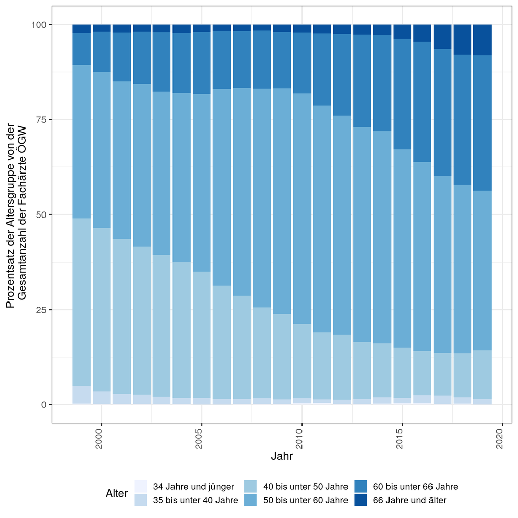

## Tabelle 1998

| Alter | Anzahl | Prozent |
| --- | --- | --- |
| 34 Jahre und jünger | 3 | 0.3 |
| 35 bis unter 40 Jahre | 48 | 4.5 |
| 40 bis unter 50 Jahre | 475 | 44.3 |
| 50 bis unter 60 Jahre | 432 | 40.3 |
| 60 bis unter 66 Jahre | 90 | 8.4 |
| 66 Jahre und älter | 24 | 2.2 |

## Tabelle 2018

| Alter | Anzahl | Prozent |
| --- | --- | --- |
| 34 Jahre und jünger | 0 | 0.0 |
| 35 bis unter 40 Jahre | 12 | 1.5 |
| 40 bis unter 50 Jahre | 100 | 12.8 |
| 50 bis unter 60 Jahre | 329 | 42.0 |
| 60 bis unter 66 Jahre | 280 | 35.7 |
| 66 Jahre und älter | 63 | 8.0 |

# Nach Geschlecht

Bei den Ärztekammern registrierte tätige Ärztinnen und Ärzte mit der Facharztbezeichnung ÖGW nach Alter in Deutschland von 1998 bis 2018 für beide Geschlechter

| Alter | Anzahl (%) in 1998 | Anzahl (%) in 2018 |
| --- | --- | --- |
| 34 Jahre und jünger | 3 (0.3%) | 0 (0%) |
| 35 bis unter 40 Jahre | 48 (4.5%) | 12 (1.5%) |
| 40 bis unter 50 Jahre | 475 (44.3%) | 100 (12.8%) |
| 50 bis unter 60 Jahre | 432 (40.3%) | 329 (42%) |
| 60 bis unter 66 Jahre | 90 (8.4%) | 280 (35.7%) |
| 66 Jahre und älter | 24 (2.2%) | 63 (8%) |

# Alterspyramide

Bei den Ärztekammern registrierte tätige Ärztinnen und Ärzte mit der Facharztbezeichnung ÖGW und alle Fachärzte nach Geschlecht und Alter (Alterspyramide) in Deutschland von 1998 bis 2018

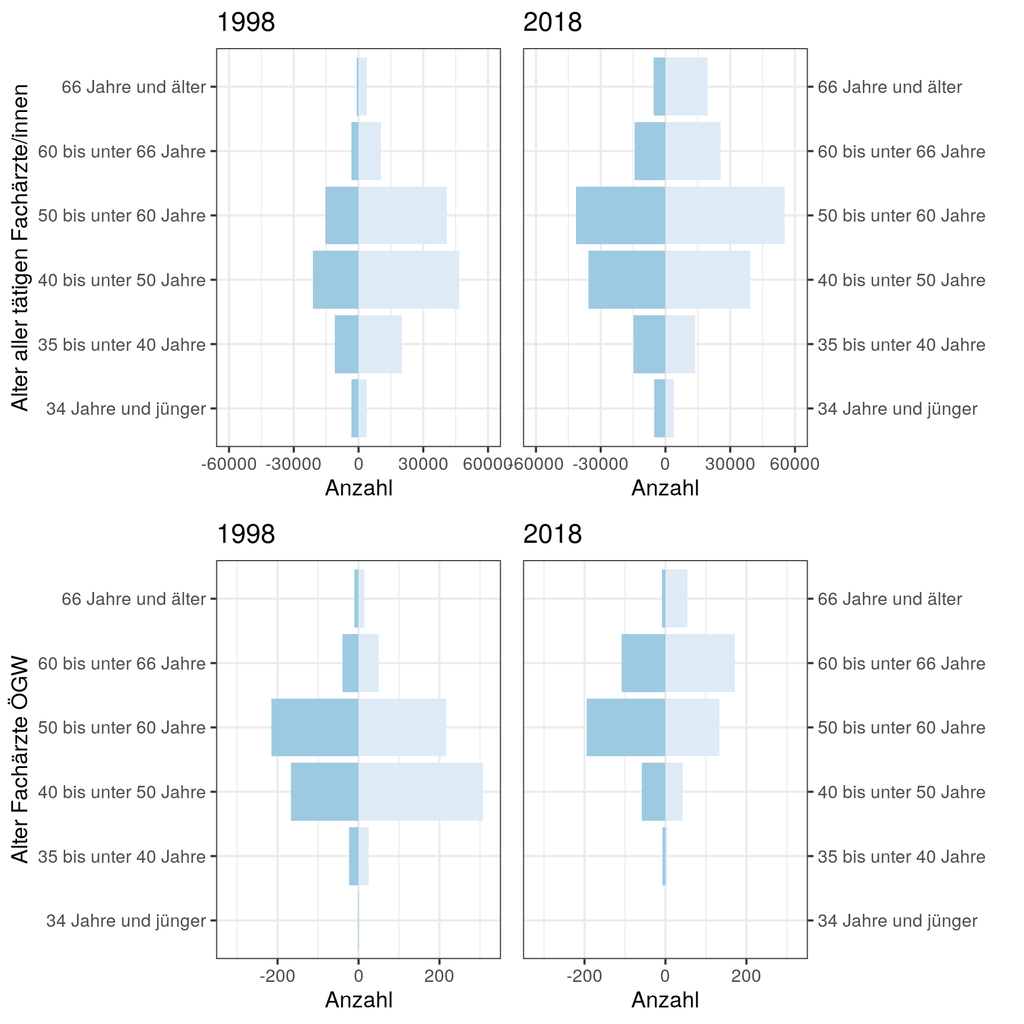

# Altersverteilung

Alter der tätigen Fachärzte nach Facharztgebiet im Jahr 1998 und Jahr 2018

| Facharzt | Jahr1998 | Jahr2018 | Differenz |
| --- | --- | --- | --- |
| Alle Fachärzte | 47.9 | 51.6 | 3.7 |
| Allgemeinmedizin | 49.0 | 55.2 | 6.2 |
| Anästhesiologie | 45.3 | 50.0 | 4.7 |
| Anatomie | 48.6 | 53.6 | 5.0 |
| Arbeitsmedizin | 49.3 | 53.6 | 4.3 |
| Augenheilkunde | 47.6 | 51.7 | 4.1 |
| Biochemie | 49.3 | 59.5 | 10.2 |
| Chirurgie | 47.6 | 50.6 | 3.0 |
| Frauenheilkunde und Geburtshilfe | 48.3 | 51.5 | 3.2 |
| Hals-Nasen-Ohrenheilkunde | 47.4 | 51.5 | 4.1 |
| Haut- und Geschlechtskrankheiten | 47.2 | 51.3 | 4.1 |
| Humangenetik | 47.0 | 51.4 | 4.4 |
| Hygiene und Umweltmedizin | 51.3 | 54.2 | 2.9 |
| Innere Medizin | 48.5 | 50.7 | 2.2 |
| Kinder- und Jugendmedizin | 48.4 | 50.3 | 1.9 |
| Kinder- und Jugendpsychiatrie und -psychotherapie | 47.5 | 51.0 | 3.5 |
| Laboratoriumsmedizin | 49.8 | 53.7 | 3.9 |
| Mikrobiologie, Virologie, Infektionsepidemiologie | 48.1 | 52.1 | 4.0 |
| Mund-Kiefer-Gesichtschirurgie | 46.4 | 51.7 | 5.3 |
| Neurochirurgie | 45.9 | 48.7 | 2.8 |
| Neurologie | 43.0 | 47.3 | 4.3 |
| Nuklearmedizin | 47.2 | 52.0 | 4.8 |
| Öffentliches Gesundheitswesen | 50.2 | 56.9 | 6.7 |
| Pathologie | 49.3 | 51.9 | 2.6 |
| Pharmakologie | 49.9 | 54.7 | 4.8 |
| Physikalische und Rehabilitative Medizin | 47.3 | 55.6 | 8.3 |
| Physiologie | 48.9 | 55.4 | 6.5 |
| Psychiatrie und Psychotherapie | 44.1 | 52.4 | 8.3 |
| Psychosomatische Medizin und Psychotherapie | 49.4 | 59.1 | 9.7 |
| Radiologie | 47.5 | 50.1 | 2.6 |
| Rechtsmedizin | 49.6 | 51.6 | 2.0 |
| Strahlentherapie | 44.2 | 50.0 | 5.8 |
| Transfusionsmedizin | 46.9 | 53.7 | 6.8 |
| Urologie | 47.7 | 50.6 | 2.9 |